# Contents

- 0 Introduction
- 1 Importing & Preprocessing Data
- 2 Modelling
  - 2.1 1st Model
  - 2.2 2nd Model
- 3 Training
  - 3.1 1st Model
  - 3.2 2nd Model
- 4 Evaluation
  - 4.1 1st Model
  - 4.2 2nd Model
- 5 Submission
  - 5.1 1st Model
  - 5.2 2nd Model

# 0 Introduction

This time we are provided MNIST data from Kaggle. MNIST data is collection of 70,000 handwritten digits images. Our goal is to build a model that classify each image of MNIST data to 10 different class or digit (0, 1, 2, 3, 4, 5, 6, 7, 8, and 9). The data is separated between the training and test dataset with the 60:40 proportion. In other to evaluate our model, we need to match our predicted data to the actual data in the Kaggle website.

We want to make prediction models using Convolutional Neural Network (CNN). The MNIST image originally in 28x28 format but the data from kaggle is in flatenned format so we need to do some preprocessing to convert it to the original image dimension.

# 1 Importing & Preprocessing Data

```python
# Load common libraries
import sys
import tensorflow as tf
import pandas as pd
import numpy as np
import matplotlib.pyplot as plt

print("Python version: {}". format(sys.version))
print("TensorFlow version:", tf.__version__)
print("Pandas version:", pd.__version__)
print("Numpy version:", np.__version__, "\n")

# We want to make sure that we use GPU for a faster training
print("Num GPUs Available: ", len(tf.config.list_physical_devices('GPU')))
```

```
Python version: 3.10.13 | packaged by Anaconda, Inc. | (main, Sep 11 2023, 13:24:38) [MSC v.1916 64 bit (AMD64)]
TensorFlow version: 2.10.1
Pandas version: 2.2.1
Numpy version: 1.26.4

Num GPUs Available:  1
```

```python
# Import data
train = pd.read_csv("train.csv")
test = pd.read_csv("test.csv")

print(type(train))
print("train shape: ", train.shape)
print("test shape: ", test.shape, "\n")

# Split the features and labels
x_train, y_train = train.iloc[:, 1:], train['label']

# Convert the data into numpy array
x_train = x_train.to_numpy()
y_train = y_train.to_numpy()
x_test = test.to_numpy()

print(type(x_train))
print("x_train shape: ", x_train.shape)
print("y_train shape: ", y_train.shape)
print("x_test shape: ", x_test.shape, "\n")

# Check the data proportion
print("train data: ", (len(x_train)/(len(x_train)+len(x_test)))*100, "%")
print("test data: ", (len(x_test)/(len(x_train)+len(x_test)))*100, "%")
```

```
<class 'pandas.core.frame.DataFrame'>
train shape:  (42000, 785)
test shape:  (28000, 784)

<class 'numpy.ndarray'>
x_train shape:  (42000, 784)
y_train shape:  (42000,)
x_test shape:  (28000, 784)

train data:  60.0 %
test data:  40.0 %
```

```python
# Peek the data
train.head(5)
```

|  | label | pixel0 | pixel1 | pixel2 | pixel3 | pixel4 | pixel5 | pixel6 | pixel7 | pixel8 | ... | pixel774 | pixel775 | pixel776 | pixel777 | pixel778 | pixel779 | pixel780 | pixel781 | pixel782 | pixel783 |
| --- | --- | --- | --- | --- | --- | --- | --- | --- | --- | --- | --- | --- | --- | --- | --- | --- | --- | --- | --- | --- | --- |
| 0 | 1 | 0 | 0 | 0 | 0 | 0 | 0 | 0 | 0 | 0 | ... | 0 | 0 | 0 | 0 | 0 | 0 | 0 | 0 | 0 | 0 |
| 1 | 0 | 0 | 0 | 0 | 0 | 0 | 0 | 0 | 0 | 0 | ... | 0 | 0 | 0 | 0 | 0 | 0 | 0 | 0 | 0 | 0 |
| 2 | 1 | 0 | 0 | 0 | 0 | 0 | 0 | 0 | 0 | 0 | ... | 0 | 0 | 0 | 0 | 0 | 0 | 0 | 0 | 0 | 0 |
| 3 | 4 | 0 | 0 | 0 | 0 | 0 | 0 | 0 | 0 | 0 | ... | 0 | 0 | 0 | 0 | 0 | 0 | 0 | 0 | 0 | 0 |
| 4 | 0 | 0 | 0 | 0 | 0 | 0 | 0 | 0 | 0 | 0 | ... | 0 | 0 | 0 | 0 | 0 | 0 | 0 | 0 | 0 | 0 |

5 rows × 785 columns

```python
# Peek the data
x_train
```

```
array([[0, 0, 0, ..., 0, 0, 0],
       [0, 0, 0, ..., 0, 0, 0],
       [0, 0, 0, ..., 0, 0, 0],
       ...,
       [0, 0, 0, ..., 0, 0, 0],
       [0, 0, 0, ..., 0, 0, 0],
       [0, 0, 0, ..., 0, 0, 0]], dtype=int64)
```

```python
# Peek the data
class_names = ['0', '1', '2', '3', '4', '5', '6', '7', '8', '9']

def show_images(x_train,
                class_names,
                y_train,
                nb_samples = 12, nb_row = 4):

    plt.figure(figsize=(12, 12))
    for i in range(nb_samples):
        plt.subplot(nb_row, nb_row, i + 1)
        plt.xticks([])
        plt.yticks([])
        plt.grid(False)
        plt.imshow(x_train[i].reshape(28,28), cmap=plt.cm.binary)
        plt.xlabel(class_names[y_train[i]])
    plt.show()
```

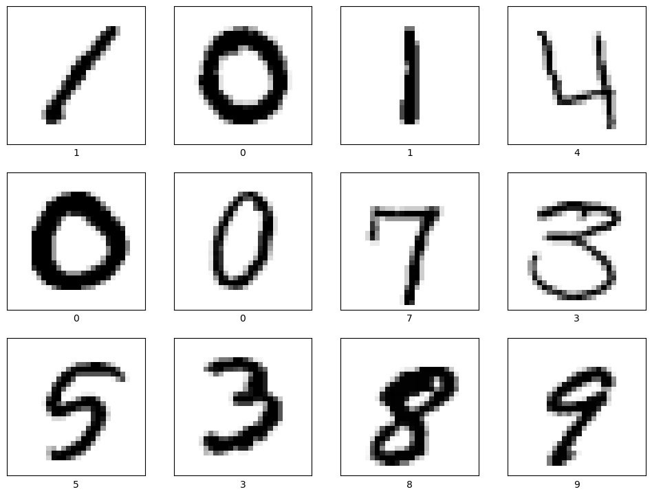

```python
# Peek the data
show_images(x_train, class_names, y_train)
```

```python
print(type(y_train))
print("y_train: ", y_train.shape, "\n")

# Convert the label variable to categorical
from tensorflow.keras.utils import to_categorical
class_names = ['0', '1', '2', '3', '4', '5', '6', '7', '8', '9']
y_train = to_categorical(y_train, len(class_names))
print(type(y_train))
print("y_train: ", y_train.shape, "\n")

# Standardize the pixel value
x_train = x_train / 255
x_test = x_test / 255
print(type(x_train))
print("x_train: ", x_train.shape)
print("x_test: ", x_test.shape, "\n")

# Convert numpy to tensor
x_train = tf.convert_to_tensor(x_train, dtype=tf.float32)
y_train = tf.convert_to_tensor(y_train, dtype=tf.float32)
x_test = tf.convert_to_tensor(x_test, dtype=tf.float32)
print(type(x_train))
print("x_train: ", x_train.shape)
print("x_test: ", x_test.shape)
print(type(y_train))
print("y_train: ", y_train.shape, "\n")

# Reshape the dimension for CNN (from flatenned to standard image dimension)
from tensorflow.python.ops.numpy_ops import np_config
x_train = x_train.reshape(x_train.shape[0], 28, 28)
x_test = x_test.reshape(x_test.shape[0], 28, 28)
print(type(x_train))
print("x_train: ", x_train.shape)
print("x_test: ", x_test.shape, "\n")
```

```
<class 'numpy.ndarray'>
y_train:  (42000,)

<class 'numpy.ndarray'>
y_train:  (42000, 10)

<class 'numpy.ndarray'>
x_train:  (42000, 784)
x_test:  (28000, 784)

<class 'tensorflow.python.framework.ops.EagerTensor'>
x_train:  (42000, 784)
x_test:  (28000, 784)
<class 'tensorflow.python.framework.ops.EagerTensor'>
y_train:  (42000, 10)

<class 'tensorflow.python.framework.ops.EagerTensor'>
x_train:  (42000, 28, 28)
x_test:  (28000, 28, 28)
```

Data normalization is important to speed up the training process. Normalization would cause the back-propagation converges much faster

# 2 Modelling

## 2.1 1st Model

```python
model_custom = tf.keras.Sequential([
            # YOUR CODE STARTS HERE                                                #(64, 64, 3)
            tf.keras.layers.ZeroPadding2D(padding=3, input_shape = (64, 64, 3)),   #(70, 70, 3)
            tf.keras.layers.Conv2D(filters = 32, kernel_size = 7, strides=1),      #(64, 64, 32)
            tf.keras.layers.BatchNormalization(axis=3),                            #(64, 64, 32)
            tf.keras.layers.ReLU(),                                                #(64, 64, 32)
            tf.keras.layers.MaxPooling2D(),                                        #(32, 32, 32)
            tf.keras.layers.Flatten(),                                             #(32768, 1)
            tf.keras.layers.Dense(units = 1, activation = 'sigmoid')
            # YOUR CODE ENDS HERE
        ])
```

```python
# GRADED FUNCTION: convolutional_model
model_custom = tf.keras.Sequential([
    tf.keras.layers.Conv2D(filters = 8, kernel_size = 4, strides  = 1, padding = 'same', input_shape = (28, 28, 1)),
    tf.keras.layers.ReLU(),
    tf.keras.layers.MaxPooling2D(pool_size = 8, strides  = 8, padding = 'same'),
    tf.keras.layers.Conv2D(filters = 16, kernel_size = 2, strides  = 1, padding = 'same'),
    tf.keras.layers.ReLU(),
    tf.keras.layers.MaxPooling2D(pool_size = 4, strides  = 4, padding = 'same'),
    tf.keras.layers.Flatten(),
    tf.keras.layers.Dense(units = 10, activation = 'softmax')
    ])

model_custom.summary()
```

```
Model: "sequential_2"
_________________________________________________________________
 Layer (type)                Output Shape              Param #
=================================================================
 conv2d_4 (Conv2D)           (None, 28, 28, 8)         136

 re_lu_4 (ReLU)              (None, 28, 28, 8)         0

 max_pooling2d_4 (MaxPooling  (None, 4, 4, 8)          0
 2D)

 conv2d_5 (Conv2D)           (None, 4, 4, 16)          528

 re_lu_5 (ReLU)              (None, 4, 4, 16)          0

 max_pooling2d_5 (MaxPooling  (None, 1, 1, 16)         0
 2D)

 flatten_2 (Flatten)         (None, 16)                0

 dense_2 (Dense)             (None, 10)                170

=================================================================
Total params: 834
Trainable params: 834
Non-trainable params: 0
_________________________________________________________________
```

## 2.2 2nd Model

```python
# Build the CNN model
from tensorflow.keras.models import Sequential
model = Sequential([
    tf.keras.layers.Conv2D(32, kernel_size=(3, 3), activation='relu', input_shape=(28, 28, 1)),
    tf.keras.layers.MaxPooling2D(pool_size=(2, 2)),
    tf.keras.layers.Conv2D(64, kernel_size=(3, 3), activation='relu'),
    tf.keras.layers.MaxPooling2D(pool_size=(2, 2)),
    tf.keras.layers.Flatten(),
    tf.keras.layers.Dense(128, activation='relu'),
    tf.keras.layers.Dropout(0.5),
    tf.keras.layers.Dense(10, activation='softmax')
])

# Compile the model
model.compile(optimizer='adam',
              loss='categorical_crossentropy',
              metrics=['accuracy'])

# Print model summary
model.summary()
```

```
Model: "sequential_3"
_________________________________________________________________
 Layer (type)                Output Shape              Param #
=================================================================
 conv2d_6 (Conv2D)           (None, 26, 26, 32)        320

 max_pooling2d_6 (MaxPooling  (None, 13, 13, 32)       0
 2D)

 conv2d_7 (Conv2D)           (None, 11, 11, 64)        18496

 max_pooling2d_7 (MaxPooling  (None, 5, 5, 64)         0
 2D)

 flatten_3 (Flatten)         (None, 1600)              0

 dense_3 (Dense)             (None, 128)               204928

 dropout (Dropout)           (None, 128)               0

 dense_4 (Dense)             (None, 10)                1290

=================================================================
Total params: 225,034
Trainable params: 225,034
Non-trainable params: 0
_________________________________________________________________
```

# 3 Training

## 3.1 1st Model

```python
from tensorflow.keras.metrics import Precision, Recall

BATCH_SIZE = 128
EPOCHS = 100

METRICS = metrics=['accuracy',
                   Precision(name='precision'),
                   Recall(name='recall')]

model_custom.compile(optimizer='adam',
              loss='categorical_crossentropy',
              metrics = METRICS)

# Train the model
training_history_model_custom = model_custom.fit(x_train, y_train,
                    epochs=EPOCHS, batch_size=BATCH_SIZE)
```

[output not shown]

[output cut: 61 more lines]

[output not shown]

## 3.2 2nd Model

```python
from tensorflow.keras.metrics import Precision, Recall

BATCH_SIZE = 128
EPOCHS = 100

METRICS = metrics=['accuracy',
                   Precision(name='precision'),
                   Recall(name='recall')]

model.compile(optimizer='adam',
              loss='categorical_crossentropy',
              metrics = METRICS)

# Train the model
training_history_model = model.fit(x_train, y_train,
                    epochs=EPOCHS, batch_size=BATCH_SIZE, validation_split=0.2, verbose=1)
```

[output not shown]

```python
history = model.fit(X_train, y_train, epochs=20, batch_size=128,validation_split=0.2, verbose=1)
```

[output not shown]

# 4 Evaluation

```python
def show_performance_curve(training_result, metric, metric_label):
    import numpy as np
    import matplotlib.pyplot as plt

    train_perf = training_result.history[str(metric)]


    plt.plot(train_perf, label=metric_label + ' (Training)')

    plt.title('Training and Validation ' + metric_label)
    plt.xlabel('Epochs')
    plt.ylabel(metric_label)
    plt.legend()
    plt.show()
```

## 4.1 1st Model

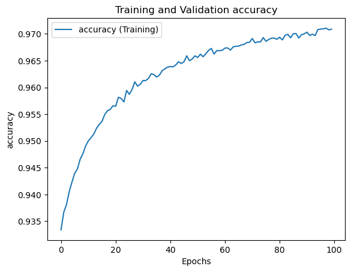

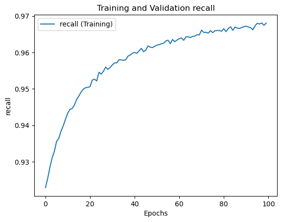

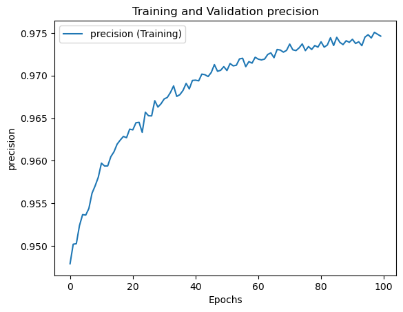

```python
show_performance_curve(training_history_model_custom, 'accuracy', 'accuracy')
show_performance_curve(training_history_model_custom, 'recall', 'recall')
show_performance_curve(training_history_model_custom, 'precision', 'precision')
```